# CIROQUO

04/2022

## Software development

- Goals:
  - easier “technological” **implementation** of methodologies from CIROQUO
  - **valuing & disseminating** CIROQUO research products
- Limits:
  - do not restrict CIROQUO’s R&D activities
  - do not constrain the tech. internal choices of *PA* & *PRT*
  - parsimony of resources (ie. software are a “secondary” target for CIROQUO)
- Means:
  - software experts
  - internal skills *PRT* & *PA*
  - financial resources
  - pre-existing Open Source tools
  - DICE / ReDICE / OQUAIDO history

## Software development

- Constraints:
  - **multilingualism**
  - internal existing practice *PA* & *PRT*
- Opportunities:
  - **multilingualism**
  - **libKriging** experiment
- Planning:
  - **COP** arbitration
  - **spontaneous** contributions
  - balance between **user priority** vs. **development opportunity**

## libKriging

“Agnostic (multi-OS, multi-lang, few deps)  
library for kriging.”

## libKriging

### Primary targets:

- **industrial grade** software: testing, integration, releasing, …
- focus on **performance**
- implement **standard** kriging methods

### Secondary aims:

- may be used as a library for **higher-level industrial software** (simulation/solver, workbench: OpenTURNS, Uranie, UQLab, …)
- should be installed & called from main **scripting math. lang** (R, Python, Octave/Matlab, …)
- whatever **environment** (Windows, Linux, Mac OS)
- should support most kriging **practice** & mimic **reference packages** (DiceKriging, DACE, RobustGaSP, …)

## libKriging: project

Hosted on https://github.com/libKriging:

- **Language**: C++ implementation
- **License**: Apache 2
- **Binding**: R, Python, Octave, Matlab
- **Testing**: from C++ *and* bindings
- **Cont. Integration** / GitHub Actions:
  - Test, Debug, Release, from
  - Windows, Linux, MacOS for
  - R, Python, Octave, Matlab
- **Benchmarking**: comparison with main kriging ref. packages
- **Release**:
  - static packages: (for most OS/lang) https://github.com/libKriging/libKriging/releases
  - installers: CRAN, Pypi, github, …

## libKriging: current release (v0.5)

- `constructor/fit`:
  - optim: none | BFGS | Newton + multistart + \({argmax_{-log(\theta)}}\{...\}\)
  - objective: logLikelihood | leaveOneOut | logMargPost
  - scaling (aka normalize X & y)
  - kernels: exp | gauss | matern 3/2 | matern 5/2
  - trend: constant | linear | interactive | quadratic
- methods:
  - `predict`: mean, stdev, cov
  - `simulate`: nsim, seed
  - `update` (not optimized)

++

- estimated nugget (no LOO, no Newton)
- memoization of objective functions (speedup and mem sparsity)

## libKriging: previous release (v0.4) - Bindings

|  | Linux Ubuntu:18 | Linux Ubuntu:20 | macOS 10 & 11 | Windows 10 |
| --- | --- | --- | --- | --- |
| Python | ✔ 3.6-3.9 | ✔ 3.6-3.9 | ✔ 3.6-3.9 | ✔ 3.6-3.9 |
| R |  | ✔ 4.1 | ✔ 4.1 | ? 4.1 |
| Octave |  | ✔ 5.2.0 | ✔ 6.2 | ✔ 5.2, ✘6.2 |
| Matlab | ⌛️ R2021 | ✘ R2021 | ✔ R2021 | ? |

## libKriging: current release (v0.5) - Bindings

|  | Linux Ubuntu:20 | macOS 10 & 11 (x86-64) | macOS 12 (ARM) | Windows 10 |
| --- | --- | --- | --- | --- |
| Python | ✔ 3.6-3.10 | ✔ 3.6-3.10 | ✔ 3.9 | ✔ 3.6-3.9 |
| R | ✔ 3.6-4.1 | ✔ 3.6-4.1 |  | ✔ 3.6-4.1 |
| Octave | ✔ 5.2.0 | ✔ 6.2 | ✔ 6.4 | ✔ 5.2, ✘6.2 |
| Matlab | ️✔ R2022 | ✔ R202* | ✘ R2022 | ✔ R2022 |

## Troïka

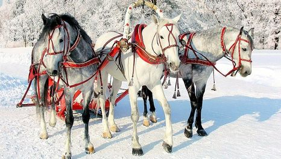

Support by Pascal, Yves & Yann:

- install requirements
- get and compile libKriging & bindings
- run basic tests

via

- Slack: https://libkriging.slack.com/
- Github: https://github.com/libKriging/libKriging/issues